# scraping football data from the web with rvest

This article was first published on https://borisls.github.io/

If you want to work with data, you need data! One data source is the web. **R** offers some packages that make it easy to scrape data from html web pages. In this example we scrape football data from Sportschau with [rvest](https://cran.r-project.org/web/packages/rvest/index.html). Sportschau is a German sport magazine on broadcaster ARD. For data access we use the mobile site http://m.sportschau.de/

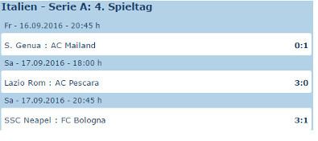

### functions for web scraping and data processing

The function `create_matchday_url` creates the URL to download the matchday results from http://m.sportschau.de/. The function inputs are  
- league: the desired football league (Bundesliga, Premier League, Primera Division or Serie A)  
- matchday: On http://m.sportschau.de/ each matchday is shown on a separate page  
- season: The current season “2016/2017” has the abbreviation “2017”

```r
create_matchday_url <- function(league, matchday, season){

  # set league identifier
  if(league=="Premier League"){
    league.id <- "ENG"
  } else if(league == "Bundesliga"){
    league.id <- "BL1"
  } else if(league == "Primera Division"){
    league.id <- "SPA"
  } else if(league == "Serie A"){
    league.id <- "ITA"
  }

  link <- paste0("http://m.sportschau.de/SportschauMobil/web/results/fb/",
                  league.id,"/",
                  season, "/1/",
                  matchday,"?sportart=Fußball")
  return(link)
}
```

For data processing you need a helper function `trim_line_sportschau`. This function removes the unneeded characters within the imported lines.

```r
trim_line_sportschau <- function(line){
  line <- str_replace_all(line, "\t", "")
  line <- str_replace_all(line, "\n", "")
  line <- str_trim(line)
  return(line)
}
```

The function `replace_character` replaces some special characters. If you use “UTF-8” encoding this function should be unnessary.

```r
replace_character <- function(x){
  x <- str_replace(string = x, "Ã¼", "ü")
  x <- str_replace(string = x, "Ã¶", "ö")
  return(x)
}
```

The function `get_matchday_results` downloads the matchday results. For this purpose, the raw data is processed and converted to a dataframe. The table contains the information about the matches and the result. The function uses the `rvest` package for downloading the raw data from http://m.sportschau.de/. The function returns a dataframe with the input parameters `league`, `matchday`, `season` and the result columns `team.home`, `team.away`, `goals.home` and `goals.away`

```r
get_matchday_results <- function(league, matchday, season){

  # download raw data with rvest
  url <- create_matchday_url(league, matchday, season)
  matchday.page <- read_html(url, encoding = "UTF-8")

  matches  <- matchday.page %>%
              html_nodes(".begegnung") %>%
              html_nodes(".mannschaften") %>%
              html_text()

  results <- matchday.page %>%
             html_nodes(".begegnung") %>%
             html_nodes(".ergebnis") %>%
             html_text()

  nr.matches <- length(matches)

  # data processing
  matchday.results <- data.frame(league = rep(league, nr.matches),
                                 matchday = rep(matchday, nr.matches),
                                 season = rep(season, nr.matches),
                                 team.home = rep("Unknown", nr.matches),
                                 team.away = rep("Unknown",nr.matches),
                                 goals.home = rep(-1, nr.matches),
                                 goals.away = rep(-1, nr.matches),
                                 stringsAsFactors=FALSE)

  for(i in 1:nr.matches){

    match <- trim_line_sportschau(line = as.character(matches[i]))
    match <- unlist(str_split(match, ":"))
    matchday.results[i, "team.home"] <- str_trim(match[1])
    matchday.results[i, "team.away"] <- str_trim(match[2])

    result <- trim_line_sportschau(line = as.character(results[i]))
    result <- unlist(str_split(result, ":"))
    matchday.results[i, "goals.home"] <- str_trim(result[1])
    matchday.results[i, "goals.away"] <- str_trim(result[2])

  }

  # Formatierungen
  matchday.results <- matchday.results %>%
                      mutate(team.home  = replace_character(team.home),
                             team.away  = replace_character(team.away),
                             goals.home = ifelse(goals.home == "-",
                                                 NA, as.integer(goals.home)),
                             goals.away = ifelse(goals.home == "-",
                                                 NA, as.integer(goals.away)))

  return(matchday.results)
}
```

The function `get_league_results` uses the function `get_matchday_results` and downloads all the matchday resultrs until the specified day.

```r
get_league_results <- function(league, played, season){

    league.results <- data.frame(league = rep(league, 500),
                                 matchday = rep(0, 500),
                                 season = rep(season, 500),
                                 team.home = rep("Unknown", 500),
                                 team.away = rep("Unknown", 500),
                                 goals.home = rep(-1, 500),
                                 goals.away = rep(-1, 500),
                                 stringsAsFactors=FALSE)
    j <- 0
    for(i in 1:played){
      df <- get_matchday_results(league, i, season)
      nr.matches <- dim(df)[1]
      league.results[(j+1):(j+nr.matches), ] <- df
      j <- j + nr.matches
    }

    league.results <- league.results %>%
                      filter(matchday != 0)

    return(league.results)
}
```

### examples

```r
get_league_results("Bundesliga", 3, 2017)
```

| league | matchday | season | team.home | team.away | goals.home | goals.away |
| --- | --- | --- | --- | --- | --- | --- |
| Bundesliga | 1 | 2017 | Bay. München | Werder Bremen | 6 | 0 |
| Bundesliga | 1 | 2017 | Bor. Dortmund | FSV Mainz 05 | 2 | 1 |
| Bundesliga | 1 | 2017 | 1. FC Köln | Darmstadt 98 | 2 | 0 |
| Bundesliga | 1 | 2017 | Hamburger SV | FC Ingolstadt | 1 | 1 |
| Bundesliga | 1 | 2017 | FC Augsburg | VfL Wolfsburg | 0 | 2 |
| Bundesliga | 1 | 2017 | E. Frankfurt | FC Schalke 04 | 1 | 0 |
| Bundesliga | 1 | 2017 | B. M’gladbach | B. Leverkusen | 2 | 1 |
| Bundesliga | 1 | 2017 | Hertha BSC | SC Freiburg | 2 | 1 |
| Bundesliga | 1 | 2017 | Hoffenheim | RB Leipzig | 2 | 2 |
| Bundesliga | 2 | 2017 | FC Schalke 04 | Bay. München | 0 | 2 |
| Bundesliga | 2 | 2017 | B. Leverkusen | Hamburger SV | 3 | 1 |
| Bundesliga | 2 | 2017 | VfL Wolfsburg | 1. FC Köln | 0 | 0 |
| Bundesliga | 2 | 2017 | FC Ingolstadt | Hertha BSC | 0 | 2 |
| Bundesliga | 2 | 2017 | Darmstadt 98 | E. Frankfurt | 1 | 0 |
| Bundesliga | 2 | 2017 | SC Freiburg | B. M’gladbach | 3 | 1 |
| Bundesliga | 2 | 2017 | RB Leipzig | Bor. Dortmund | 1 | 0 |
| Bundesliga | 2 | 2017 | Werder Bremen | FC Augsburg | 1 | 2 |
| Bundesliga | 2 | 2017 | FSV Mainz 05 | Hoffenheim | 4 | 4 |
| Bundesliga | 3 | 2017 | 1. FC Köln | SC Freiburg | 3 | 0 |
| Bundesliga | 3 | 2017 | Bay. München | FC Ingolstadt | 3 | 1 |
| Bundesliga | 3 | 2017 | Bor. Dortmund | Darmstadt 98 | 6 | 0 |
| Bundesliga | 3 | 2017 | Hamburger SV | RB Leipzig | 0 | 4 |
| Bundesliga | 3 | 2017 | Hoffenheim | VfL Wolfsburg | 0 | 0 |
| Bundesliga | 3 | 2017 | E. Frankfurt | B. Leverkusen | 2 | 1 |
| Bundesliga | 3 | 2017 | B. M’gladbach | Werder Bremen | 4 | 1 |
| Bundesliga | 3 | 2017 | FC Augsburg | FSV Mainz 05 | 1 | 3 |
| Bundesliga | 3 | 2017 | Hertha BSC | FC Schalke 04 | 2 | 0 |

```r
get_league_results("Premier League", 2, 2016)
```

| league | matchday | season | team.home | team.away | goals.home | goals.away |
| --- | --- | --- | --- | --- | --- | --- |
| Premier League | 1 | 2016 | Manchester U. | Tottenham | 1 | 0 |
| Premier League | 1 | 2016 | AFC Bournem. | Aston Villa | 0 | 1 |
| Premier League | 1 | 2016 | Norwich City | Crystal Pal. | 1 | 3 |
| Premier League | 1 | 2016 | Leicester | AFC Sunderl. | 4 | 2 |
| Premier League | 1 | 2016 | FC Everton | FC Watford | 2 | 2 |
| Premier League | 1 | 2016 | FC Chelsea | Swansea City | 2 | 2 |
| Premier League | 1 | 2016 | Newcastle Utd | Southampton | 2 | 2 |
| Premier League | 1 | 2016 | FC Arsenal | West Ham Utd. | 0 | 2 |
| Premier League | 1 | 2016 | Stoke City | FC Liverpool | 0 | 1 |
| Premier League | 1 | 2016 | West Bromwich | Manchester C. | 0 | 3 |
| Premier League | 2 | 2016 | Aston Villa | Manchester U. | 0 | 1 |
| Premier League | 2 | 2016 | Southampton | FC Everton | 0 | 3 |
| Premier League | 2 | 2016 | West Ham Utd. | Leicester | 1 | 2 |
| Premier League | 2 | 2016 | FC Watford | West Bromwich | 0 | 0 |
| Premier League | 2 | 2016 | Swansea City | Newcastle Utd | 2 | 0 |
| Premier League | 2 | 2016 | AFC Sunderl. | Norwich City | 1 | 3 |
| Premier League | 2 | 2016 | Tottenham | Stoke City | 2 | 2 |
| Premier League | 2 | 2016 | Crystal Pal. | FC Arsenal | 1 | 2 |
| Premier League | 2 | 2016 | Manchester C. | FC Chelsea | 3 | 0 |
| Premier League | 2 | 2016 | FC Liverpool | AFC Bournem. | 1 | 0 |

```r
get_matchday_results("Serie A", 17, 2017)
```

| league | matchday | season | team.home | team.away | goals.home | goals.away |
| --- | --- | --- | --- | --- | --- | --- |
| Serie A | 17 | 2017 | FC Empoli | Cagliari C. | 2 | 0 |
| Serie A | 17 | 2017 | AC Mailand | Atal. Bergamo | 0 | 0 |
| Serie A | 17 | 2017 | Juvent. Turin | AS Rom | 1 | 0 |
| Serie A | 17 | 2017 | Sass. Calcio | Inter Mailand | 0 | 1 |
| Serie A | 17 | 2017 | Chievo Verona | S. Genua | 2 | 1 |
| Serie A | 17 | 2017 | SSC Neapel | FC Turin | 5 | 3 |
| Serie A | 17 | 2017 | AC Pescara | FC Bologna | 0 | 3 |
| Serie A | 17 | 2017 | Udinese Cal. | Crotone Calc. | 2 | 0 |
| Serie A | 17 | 2017 | CFC Genua | US Palermo | 3 | 4 |
| Serie A | 17 | 2017 | Lazio Rom | AC Florenz | 3 | 1 |

```r
get_matchday_results("Primera Division", 34, 2017)
```

| league | matchday | season | team.home | team.away | goals.home | goals.away |
| --- | --- | --- | --- | --- | --- | --- |
| Primera Division | 34 | 2017 | Athl. Bilbao | Betis Sevilla | NA | NA |
| Primera Division | 34 | 2017 | CD Alaves | SD Eibar | NA | NA |
| Primera Division | 34 | 2017 | CD Leganes | UD Las Palmas | NA | NA |
| Primera Division | 34 | 2017 | A. Madrid | FC Villarreal | NA | NA |
| Primera Division | 34 | 2017 | Sport. Gijon | E. Barcelona | NA | NA |
| Primera Division | 34 | 2017 | FC Barcelona | CA Osasuna | NA | NA |
| Primera Division | 34 | 2017 | D. La Coruna | Real Madrid | NA | NA |
| Primera Division | 34 | 2017 | FC Valencia | San Sebastian | NA | NA |
| Primera Division | 34 | 2017 | FC Granada | FC Málaga | NA | NA |
| Primera Division | 34 | 2017 | FC Sevilla | Celta Vigo | NA | NA |